# Effect of Treatments on Glottic Cancer

Xiang Zhu & Shutian Lin (Group 6)

八月 02, 2021

```r
library(tidyverse)
library(readxl)
library(table1)
library(magrittr)
library(dplyr)

glottic <- read_excel("Glottic_Cancer_Data_Set_011521.xlsx")

# Check for missing value for each column
apply(glottic, 2, function(x) {
    sum(is.na(x))
})
```

```r
glottic <- glottic %>% filter(Death_Status != 1) %>% filter(!is.na(Age_dx)) %>%
    filter(Rad_Tx_Status != "U", Rad_Tx_Status == "0.00" | Rad_Tx_Status ==
        "1.00") %>% mutate(Rad_Tx_Status = as.numeric(Rad_Tx_Status)) %>%
    mutate(Death_Status = ifelse(Death_Status == 0, 0, 1)) %>%
    mutate(Race = ifelse(Race == "Black" | Race == "White", Race,
        "Others")) %>% rename(Tumor_Type = Derived_AJCC, Age = Age_dx) %>%
    select(-Survival_mos)
glottic %<>% mutate_each_(funs(factor(.)), c("Tumor_Type", "Sex",
    "Race", "Rad_Tx_Status", "Death_Status"))
```

```r
# Descriptive table of all variables stratified by death
# status
table1 <- table1(~Tumor_Type + Sex + Age + Race + Rad_Tx_Status |
    Death_Status, data = glottic)
```

### Description of the problem and scientific question

As one of the most common head and neck malignancies, glottic cancer makes up about 1% of global cancer in 2018 and causes 1% of the cancer deaths worldwide. Treatments for this type of cancer mainly involve surgery, radiation, or a combination of both surgery and radiation. The scientific question for this study is that: What is the effect of different types of treatments on the three-year survival among patients with glottic cancer?

### Description of the dataset

#### Data definitions

- Tumor_Type: American Joint Committee on Cancer staging classification system
  - T1a and T1b: The tumor is only in the vocal cords with normal mobility. T1a refers to cancer involvement of only one cord. T1b refers to cancer involvement of both cords.
  - T2: The tumor is large enough that it goes to the supraglottis and/or subglottis, and/or there is decreased movement of the vocal cord.
  - T1NOS: T1 tumor not otherwise specified.
- Sex: Female/Male
- Age: in years
- Race: White/Black/Others
- Rad_Tx_Status: Radiation/Surgery treatment status
  - 0 = Surgery
  - 1 = Radiation
- Death_Status: status at endpoint
  - 0 = Alive
  - 1 = Dead Cancer

#### Description of variables

```r
table1
```

|  | 0 (N=2460) | 1 (N=161) | Overall (N=2621) |
| --- | --- | --- | --- |
| Tumor_Type |  |  |  |
| T1a | 1164 (47.3%) | 55 (34.2%) | 1219 (46.5%) |
| T1b | 236 (9.6%) | 19 (11.8%) | 255 (9.7%) |
| T1NOS | 476 (19.3%) | 17 (10.6%) | 493 (18.8%) |
| T2 | 584 (23.7%) | 70 (43.5%) | 654 (25.0%) |
| Sex |  |  |  |
| Female | 273 (11.1%) | 21 (13.0%) | 294 (11.2%) |
| Male | 2187 (88.9%) | 140 (87.0%) | 2327 (88.8%) |
| Age |  |  |  |
| Mean (SD) | 63.8 (11.4) | 67.2 (12.8) | 64.0 (11.6) |
| Median [Min, Max] | 64.0 [16.0, 93.0] | 67.0 [42.0, 106] | 64.0 [16.0, 106] |
| Race |  |  |  |
| Black | 281 (11.4%) | 18 (11.2%) | 299 (11.4%) |
| Others | 113 (4.6%) | 5 (3.1%) | 118 (4.5%) |
| White | 2066 (84.0%) | 138 (85.7%) | 2204 (84.1%) |
| Rad_Tx_Status |  |  |  |
| 0 | 553 (22.5%) | 23 (14.3%) | 576 (22.0%) |
| 1 | 1907 (77.5%) | 138 (85.7%) | 2045 (78.0%) |

#### Correlation between variables

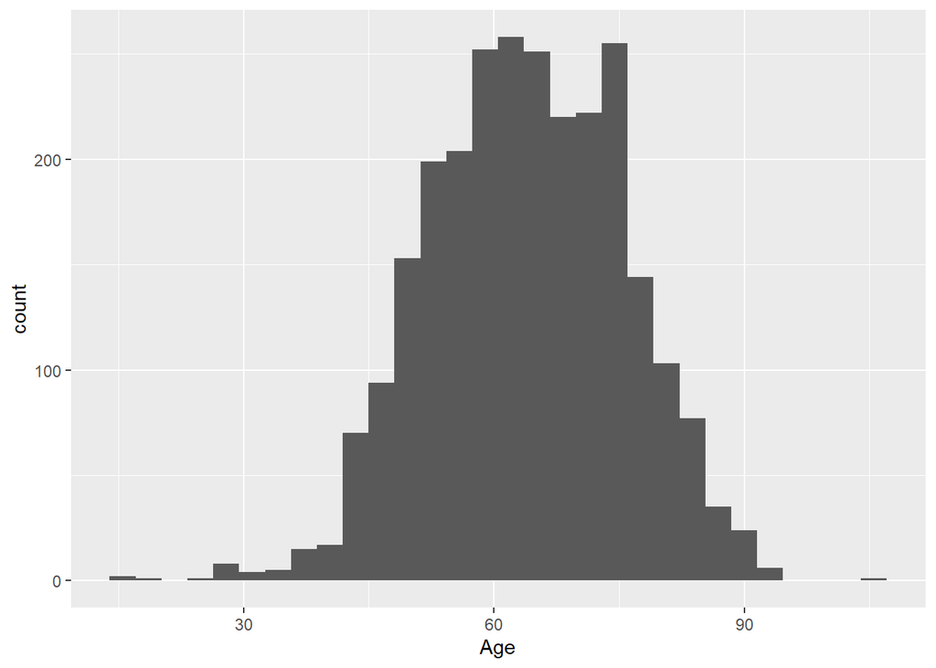

```r
ggplot(glottic, aes(Age)) + geom_histogram(bins = 30)
```

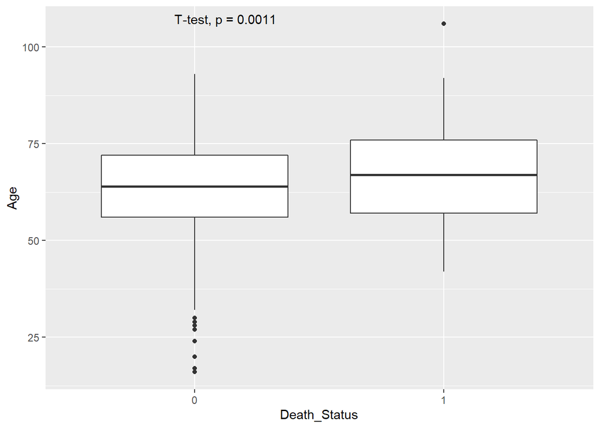

```r
library(ggpubr)
# Tumor_Type + Sex + Age + Race + Rad_Tx_Status |
# Death_Status
ggplot(glottic, aes(x = Death_Status, y = Age)) + geom_boxplot(add = "jitter") +
    stat_compare_means(method = "t.test")
```

```r
# Tumor_Type
chisq.test(glottic$Death_Status, glottic$Tumor_Type)
```

```
##
##  Pearson's Chi-squared test
##
## data:  glottic$Death_Status and glottic$Tumor_Type
## X-squared = 36.182, df = 3, p-value = 6.852e-08
```

```r
# Sex
chisq.test(glottic$Death_Status, glottic$Sex)
```

```
##
##  Pearson's Chi-squared test with Yates' continuity correction
##
## data:  glottic$Death_Status and glottic$Sex
## X-squared = 0.39577, df = 1, p-value = 0.5293
```

```r
# Race
chisq.test(glottic$Death_Status, glottic$Race)
```

```
##
##  Pearson's Chi-squared test
##
## data:  glottic$Death_Status and glottic$Race
## X-squared = 0.80469, df = 2, p-value = 0.6688
```

```r
# Rad_Tx_Status
chisq.test(glottic$Death_Status, glottic$Rad_Tx_Status)
```

```
##
##  Pearson's Chi-squared test with Yates' continuity correction
##
## data:  glottic$Death_Status and glottic$Rad_Tx_Status
## X-squared = 5.4488, df = 1, p-value = 0.01958
```

##### 1. Specify a Causal Model.

- Endogenous variables: $X=(W_1, W_2, W_3, W_4, A,Y)$
- Exogenous variables: $U=(U_{W_1},U_{W_2}, U_{W_3}, U_{W_4}, U_A,U_Y)∼P^∗$
- Structural equations F:

$$W_1 <- f_W(U_{W_1})$$
$$W_2 <- f_W(U_{W_2})$$
$$W_3 <- f_W(U_{W_3})$$
$$W_4 <- f_W(W_1， W_2， W_3，U_{W_4})$$
$$A <- f_W(U_A, W_3, W_4)$$
$$Y <- f_W(U_Y, A, W_3, W_4)$$

where $W_1$={Female, Male}, $W_2$={Age}, $W_3$={Black, White, Others}, $W_4$={T1a, T1b, T1NOS, T2}, $A$={Surgery, Radiation}, $Y$={survival}.

##### 2. Translate your question into a formal target causal parameter, defined using counter-factuals.

The target causal parameter is the difference in the counterfactual vital status through three years, if all subjects take the treatment of Radiation, and the counterfactual vital status, if all subjects take the treatment of Surgery:

$$P^*(Y_1 = 1) - P^*(Y_0 = 1) = E^*[Y_1] - E^*[Y_0]$$
where $Y_a$ denotes the counterfactual outcome under an intervention to set treatment status $A=a$.

##### 4. Identify.

In the SCM, the target causal quantity is not identified. If we have more information to have $U_A$ independent on other U, the back-door criterion holds conditional on $W = (W_3, W_4)$. Equivalently, the counterfactual outcome $Y_a$ is conditionally independent of the treatment A, given $W = (W_3, W_4)$.

For identifiability, we also need the positivity assumption to hold:

$$min_{a\in A}P(A=a|W = w) > 0, for\ all\ w\ for\ which\ P(W=w)>0$$
Here, we are using $W = (W_3, W_4)$ to denote the set of covariates that satisfy the backdoor criteria under the working SCM.

##### 5. Commit to a Statistical Model and Estimand (target parameter of the observed datadistribution).

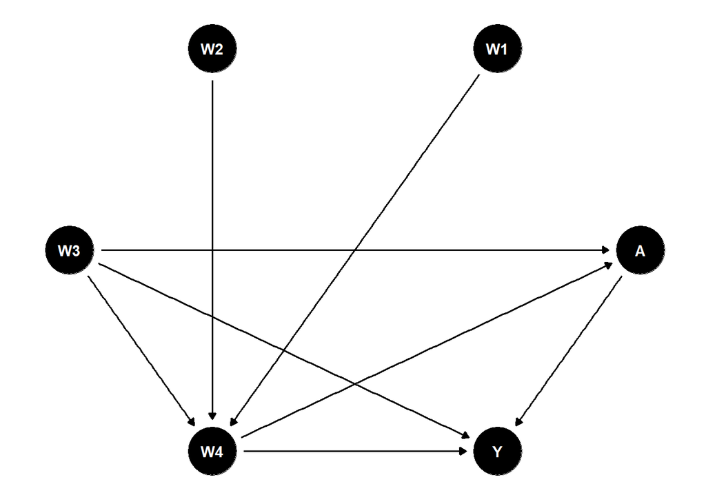

##### 6. Estimate.

```r
ObsData <- glottic
```

```r
names(ObsData)
```

```
## [1] "Tumor_Type"    "Sex"           "Age"           "Race"
## [5] "Death_Status"  "Rad_Tx_Status"
```

```r
names(ObsData) <- c("W4", "W1", "W2", "W3", "A", "Y")
names(ObsData)
```

```
## [1] "W4" "W1" "W2" "W3" "A"  "Y"
```

```r
ObsData$Y <- as.numeric(ObsData$Y) - 1
ObsData$A <- as.numeric(ObsData$A) - 1
```

$$\hat \theta = \sum_{W_3, W_4}[\hat E(Y|A=1,W_3=w_3, W_4 = w_4)-\hat E(Y|A=0,W_3=w_3, W_4 = w_4)]\hat P(W_3 = w_3, W_4 = w_4)$$

```r
n <- nrow(ObsData)
```

```r
reg_model <- glm(Y ~ A + W3 + W4 + A * W3 * W4, family = "binomial",
    data = ObsData)
reg_model
```

```
##
## Call:  glm(formula = Y ~ A + W3 + W4 + A * W3 * W4, family = "binomial",
##     data = ObsData)
##
## Coefficients:
##        (Intercept)                   A            W3Others             W3White
##            1.57898            -1.17351            -0.67611            -0.70522
##              W4T1b             W4T1NOS                W4T2          A:W3Others
##           -0.05292            -0.48037             0.76557            14.83671
##          A:W3White             A:W4T1b           A:W4T1NOS              A:W4T2
##            2.47450            14.21353            -1.01167             0.62072
##     W3Others:W4T1b       W3White:W4T1b    W3Others:W4T1NOS     W3White:W4T1NOS
##           -0.62680             1.07436             1.36926             0.78362
##      W3Others:W4T2        W3White:W4T2    A:W3Others:W4T1b     A:W3White:W4T1b
##           -0.61239             0.21550                  NA           -16.59878
## A:W3Others:W4T1NOS   A:W3White:W4T1NOS     A:W3Others:W4T2      A:W3White:W4T2
##            0.12278                  NA           -14.64683            -1.75217
##
## Degrees of Freedom: 2620 Total (i.e. Null);  2599 Residual
## Null Deviance:       2760
## Residual Deviance: 2666  AIC: 2710
```

```r
txt <- control <- ObsData
# set A=1 in the txt dataframe and A=0 in control dataframe
txt$A <- 1
control$A <- 0
```

```r
predictY_txt <- predict(reg_model, newdata = txt, type = "response")
```

```r
predictY_control <- predict(reg_model, newdata = control, type = "response")
mean(predictY_txt - predictY_control)
```

```
## [1] 0.06049875
```

##### IPTW

```r
# IPTW
prob.AW.reg <- glm(A ~ W3 + W4, family = "binomial", data = ObsData)
prob.AW.reg$coef
```

```
## (Intercept)    W3Others     W3White       W4T1b     W4T1NOS        W4T2
##  -3.1302176  -0.3530290   0.1044611   0.5333275  -0.2781738   0.9380226
```

```r
prob.1W <- predict(prob.AW.reg, type = "response")

prob.0W <- 1 - prob.1W

prob.AW <- c(1:n)

prob.AW[ObsData$A == 1] <- prob.1W[ObsData$A == 1]

prob.AW[ObsData$A == 0] <- prob.0W[ObsData$A == 0]

summary(prob.AW)
```

```
##    Min. 1st Qu.  Median    Mean 3rd Qu.    Max.
## 0.02272 0.89955 0.95372 0.88634 0.95372 0.97728
```

```r
wt <- 1/prob.AW

summary(wt)
```

```
##    Min. 1st Qu.  Median    Mean 3rd Qu.    Max.
##   1.023   1.049   1.049   1.999   1.112  44.009
```

```r
IPTW <- mean(wt * as.numeric(ObsData$A == 1) * as.numeric(ObsData$Y)) -
    mean(wt * as.numeric(ObsData$A == 0) * as.numeric(ObsData$Y))
IPTW
```

```
## [1] 0.07729494
```

```r
# Positivity assumption for iptw
wt.trunc <- wt
wt.trunc[wt.trunc > 30] <- 30  # Arbitrarily truncate the weights at 30
mean(wt.trunc * as.numeric(ObsData$A == 1) * ObsData$Y) - mean(wt.trunc *
    as.numeric(ObsData$A == 0) * ObsData$Y)
```

```
## [1] 0.07058958
```

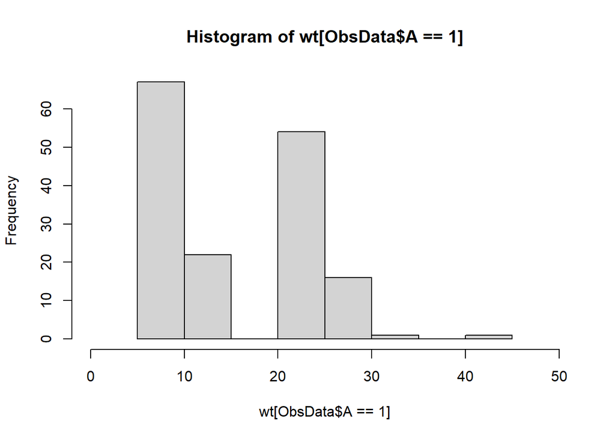

```r
# Create histograms of the propensity scores for Radiation
hist(wt[ObsData$A == 1], xlim = c(0, 50))
```

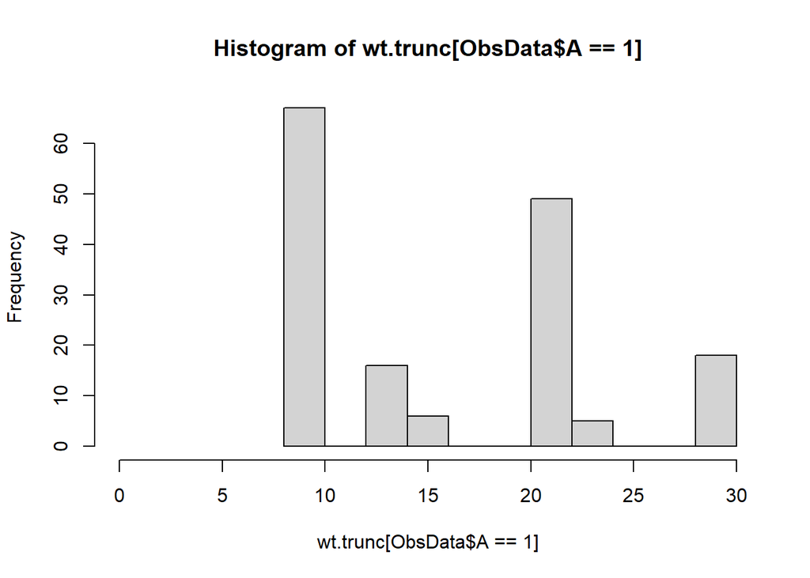

```r
hist(wt.trunc[ObsData$A == 1], xlim = c(0, 30))
```

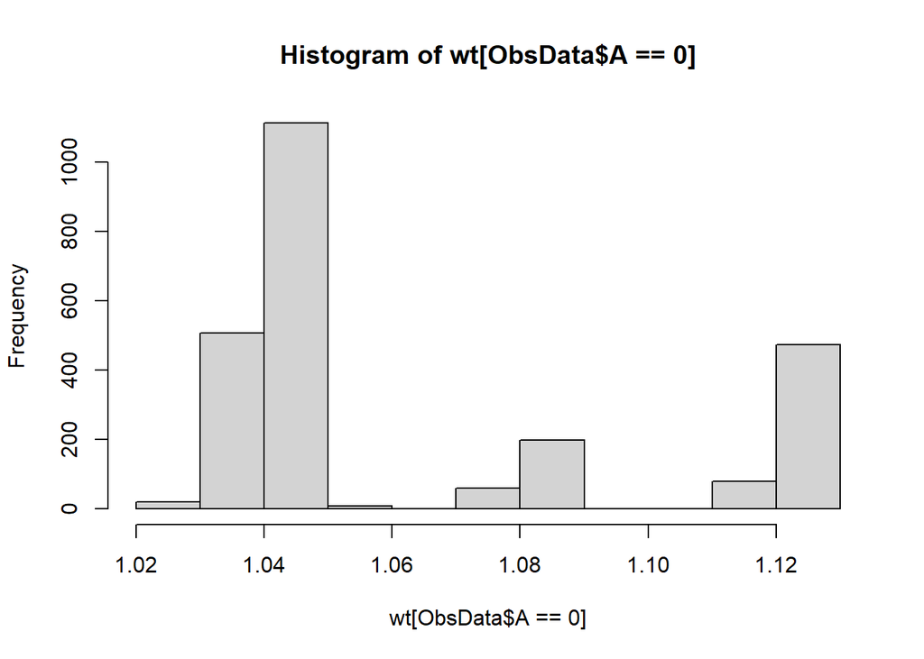

```r
# Create histograms of the propensity scores for surgery
hist(wt[ObsData$A == 0])
```

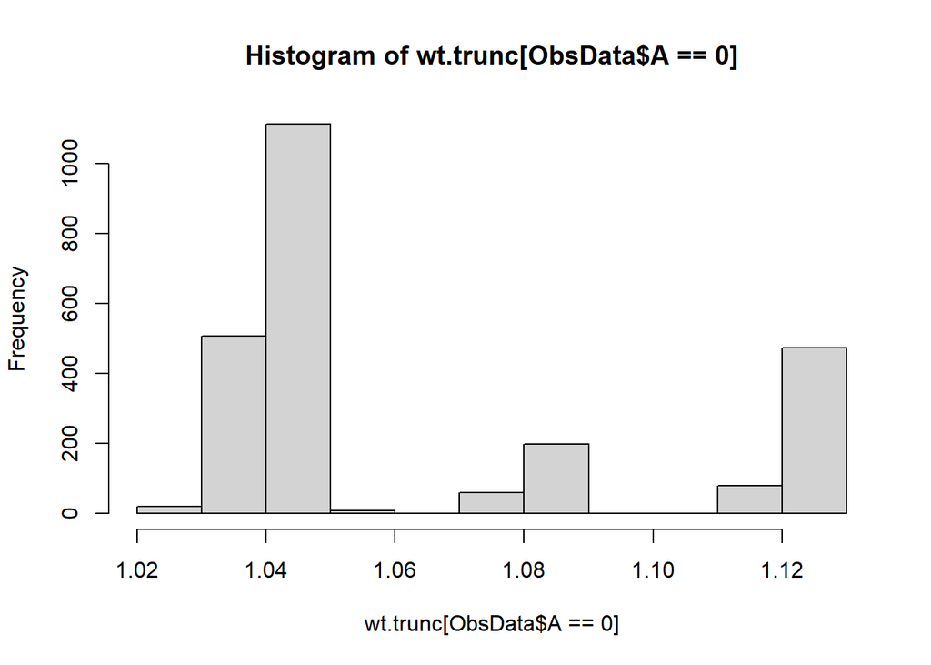

```r
hist(wt.trunc[ObsData$A == 0])
```

##### TMLE

```r
# TMLE
library(SuperLearner)
library(sl3)
```

```r
ObsData$Y <- as.numeric(ObsData$Y)
ObsData$A <- as.numeric(ObsData$A)
ObsData$W3 <- as.numeric(ObsData$W3)
ObsData$W4 <- as.numeric(ObsData$W4)
ObsData$W1 <- as.numeric(ObsData$W1)

W <- subset(ObsData, select = c(-Y, -A))
```

```r
library(tmle)
```

```r
SL_library <- c("SL.glm", "SL.step", "SL.glm.interaction", "SL.gam",
    "SL.mean")
```

```r
X <- subset(ObsData, select = -Y)
SL_out <- SuperLearner(Y = ObsData$Y, X = X, cvControl = list(V = 10),
    SL.library = SL_library)

SL_out
```

```
##
## Call:
## SuperLearner(Y = ObsData$Y, X = X, SL.library = SL_library, cvControl = list(V = 10))
##
##
##
##                             Risk       Coef
## SL.glm_All             0.1688498 0.00000000
## SL.step_All            0.1687519 0.37058798
## SL.glm.interaction_All 0.1685396 0.56620559
## SL.gam_All             0.1689659 0.00000000
## SL.mean_All            0.1715088 0.06320643
```

```r
tmle_result <- tmle(Y = ObsData$Y, A = ObsData$A, W = W)
```

```r
tmle_result
```

```
##  Additive Effect
##    Parameter Estimate:  0.079154
##    Estimated Variance:  0.00096364
##               p-value:  0.010777
##     95% Conf Interval: (0.01831, 0.14)
##
##  Additive Effect among the Treated
##    Parameter Estimate:  0.055143
##    Estimated Variance:  0.00086639
##               p-value:  0.061012
##     95% Conf Interval: (-0.0025487, 0.11283)
##
##  Additive Effect among the Controls
##    Parameter Estimate:  0.080272
##    Estimated Variance:  0.00097473
##               p-value:  0.010137
##     95% Conf Interval: (0.01908, 0.14146)
```

```r
# AIPW
library(lmtp)
```

##### AIPW

```r
# AIPW
library(AIPW)
library(ggplot2)
```

```
##                  Estimate      SE 95% LCL 95% UCL    N
## Risk of exposure   0.8560 0.02988  0.7975   0.915  161
## Risk of control    0.7769 0.00838  0.7604   0.793 2460
## Risk Difference    0.0792 0.03104  0.0183   0.140 2621
## Risk Ratio         1.1019 0.03656  1.0257   1.184 2621
## Odds Ratio         1.7076 0.24733  1.0516   2.773 2621
```

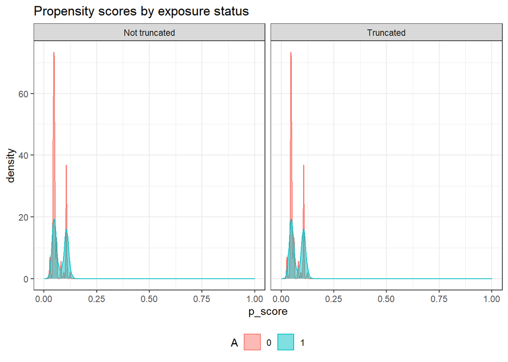

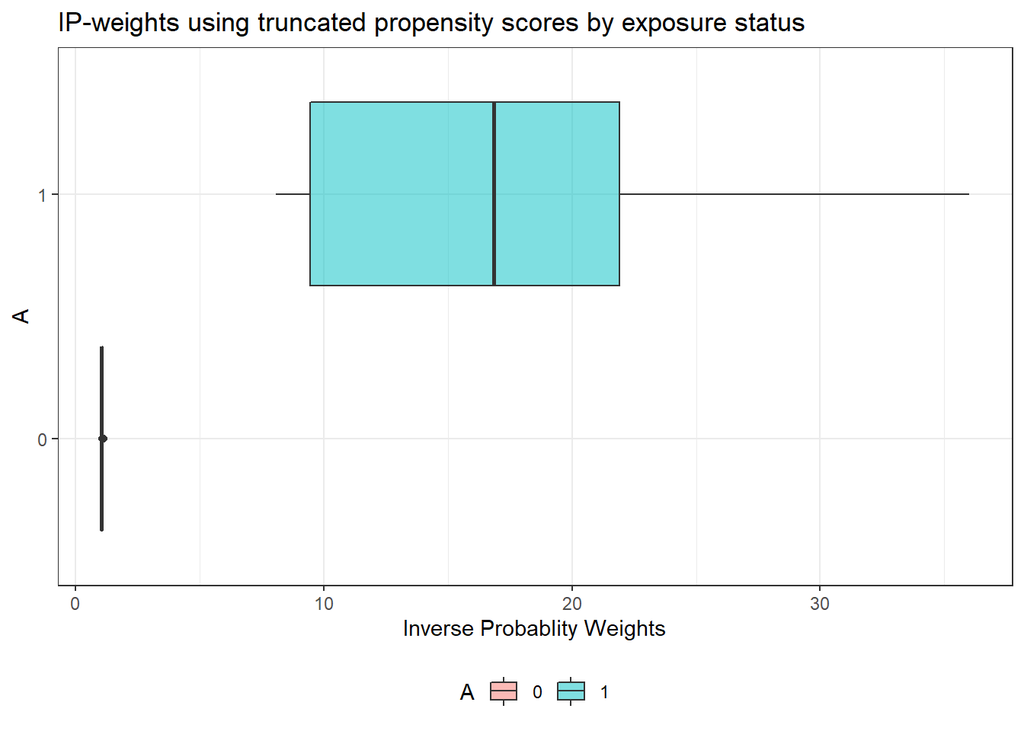

```r
AIPW_tmle$new(A = ObsData$A, Y = ObsData$Y, tmle_fit = tmle_result,
    verbose = TRUE)$summary(g.bound = 0.025)$plot.p_score()$plot.ip_weights()
```